# Final Project: Recommendation Systems

In order to compare different models, define them as a following list:

- Item-based collaborative filtering, using the Cosine as the distance function
- Item-based collaborative filtering, using the Pearson correlation as the distance function
- User-based collaborative filtering, using the Cosine as the distance function
- User-based collaborative filtering, using the Pearson correlation as the distance function
- Random recommendations to have a base line

```r
models_to_evaluate <- list(
IBCF_cos = list(name = "IBCF",
                param = list(method = "cosine")),
IBCF_cor = list(name = "IBCF",
                param = list(method = "pearson")),
UBCF_cos = list(name = "UBCF",
                param = list(method = "cosine")),
UBCF_cor = list(name = "UBCF",
                param = list(method = "pearson")),
random = list(name = "RANDOM", param=NULL)
)
```

Define a different set of numbers for recommended movies (n_recommendations <- c(1, 5, seq(10, 100, 10))), run and evaluate the models:

```r
n_recommendations <- c(1, 5, seq(10, 100, 10))
list_results <- evaluate(x = eval_sets,
                         method = models_to_evaluate,
                         n = n_recommendations)
```

```
## IBCF run fold/sample [model time/prediction time]
##   1  [0.215sec/0.019sec]
##   2  [0.195sec/0.018sec]
##   3  [0.21sec/0.018sec]
##   4  [0.207sec/0.016sec]
## IBCF run fold/sample [model time/prediction time]
##   1  [0.222sec/0.018sec]
##   2  [0.214sec/0.019sec]
##   3  [0.222sec/0.031sec]
##   4  [0.219sec/0.018sec]
## UBCF run fold/sample [model time/prediction time]
##   1  [0.002sec/0.055sec]
##   2  [0.002sec/0.053sec]
##   3  [0.001sec/0.053sec]
##   4  [0.002sec/0.052sec]
## UBCF run fold/sample [model time/prediction time]
##   1  [0.001sec/0.062sec]
##   2  [0.002sec/0.059sec]
##   3  [0.002sec/0.059sec]
##   4  [0.002sec/0.058sec]
## RANDOM run fold/sample [model time/prediction time]
##   1  [0sec/0.024sec]
##   2  [0.001sec/0.023sec]
##   3  [0sec/0.023sec]
##   4  [0sec/0.022sec]
```

```r
sapply(list_results, class) == "evaluationResults"
```

```
## IBCF_cos IBCF_cor UBCF_cos UBCF_cor   random
##     TRUE     TRUE     TRUE     TRUE     TRUE
```

The following table presents as an example the first rows of the performance evaluation matrix for the IBCF with Cosine distance:

```r
avg_matrices <- lapply(list_results, avg)
names(avg_matrices)
```

```
## [1] "IBCF_cos" "IBCF_cor" "UBCF_cos" "UBCF_cor" "random"
```

```r
head(avg_matrices$IBCF_cos)
```

```
##           TP         FP       FN       TN precision      recall
## 1  0.1166667  0.8708333 44.17500 230.8375 0.1178794 0.004435477
## 5  0.7708333  4.1666667 43.52083 227.5417 0.1562975 0.020950165
## 10 1.5291667  8.3458333 42.76250 223.3625 0.1548522 0.039344802
## 20 3.1083333 16.5541667 41.18333 215.1542 0.1584605 0.077549341
## 30 4.3916667 24.9583333 39.90000 206.7500 0.1501401 0.103216499
## 40 5.6333333 32.9500000 38.65833 198.7583 0.1465304 0.129936641
##            TPR         FPR
## 1  0.004435477 0.003877443
## 5  0.020950165 0.018216621
## 10 0.039344802 0.036396531
## 20 0.077549341 0.072177611
## 30 0.103216499 0.108743333
## 40 0.129936641 0.143663136
```

Identifying the most suitable model

Compare the models by building a chart displaying their ROC curves and Precision/recall curves.

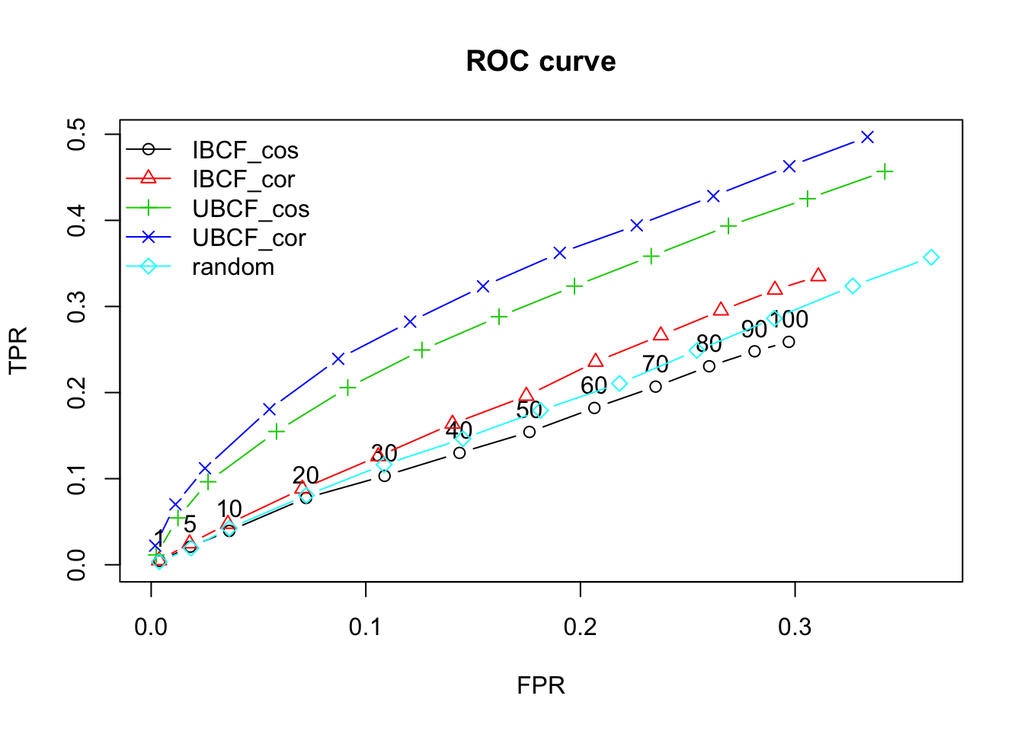

```r
plot(list_results, annotate = 1, legend = "topleft")
title("ROC curve")
```

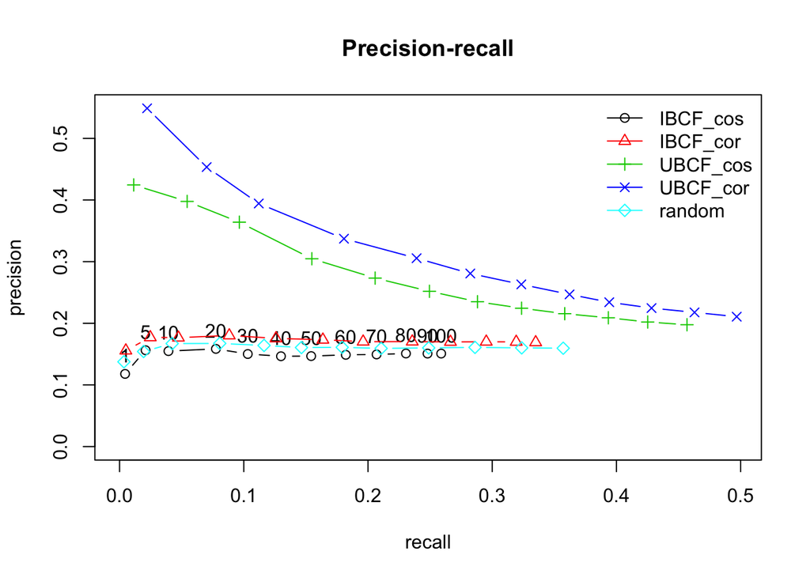

```r
plot(list_results, "prec/rec", annotate = 1, legend = "topright")
title("Precision-recall")
```

A good performance index is the area under the curve (AUC), that is, the area under the ROC curve. Even without computing it, the chart shows that the highest is UBCF with Pearson distance, so it’s the best-performing technique.

The advantage of User based Collaborative Filtering is that it gives recommendations that can be complements to the movies the user has rated. This might be a stronger recommendation than with movie based recommender as users might not be looking for direct substitutes to a movie.

The disadvantage of User based Collaborative filtering is that it’s a type of memory based collaborative filtering that uses all user data in the database to create recommendations. It has the issue of huge computational cost ad limited scalability. Also UBCF relies on the past user choices to make future recommendations and this might be true always.